# R Notebook

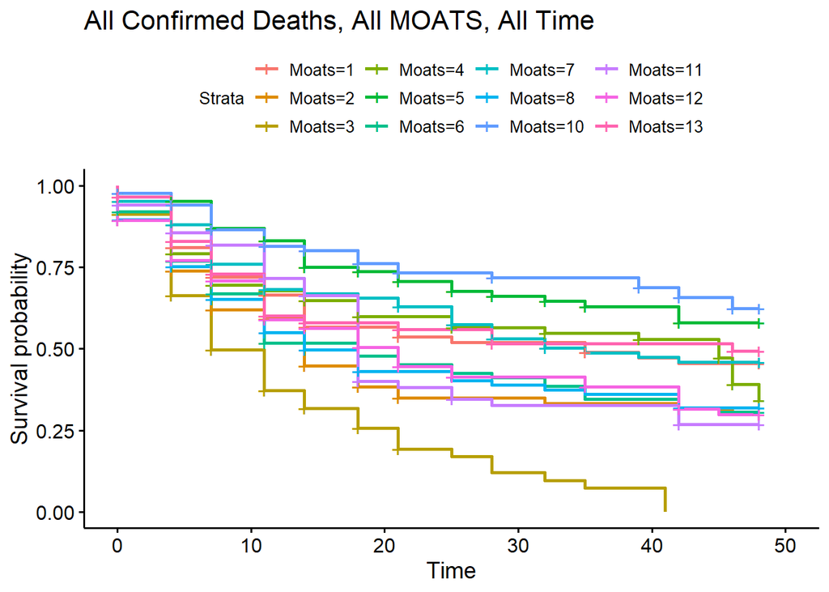

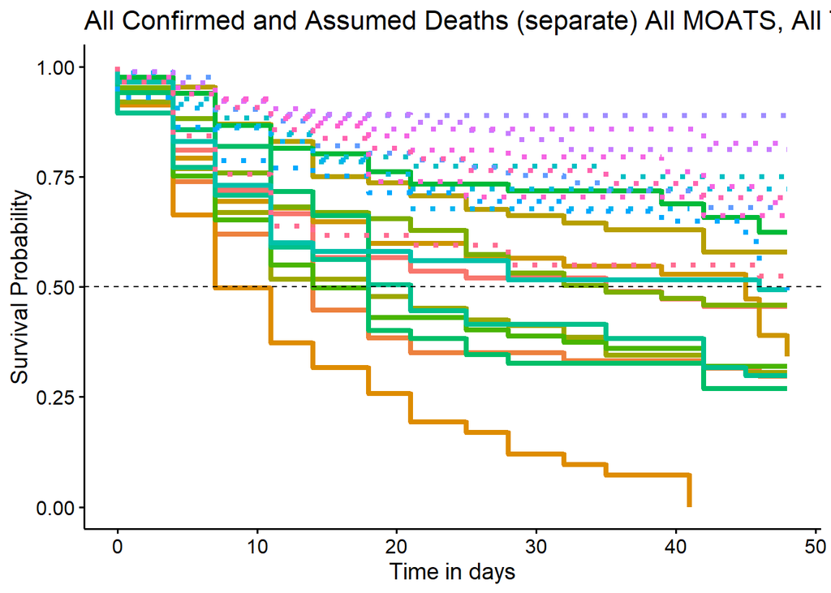

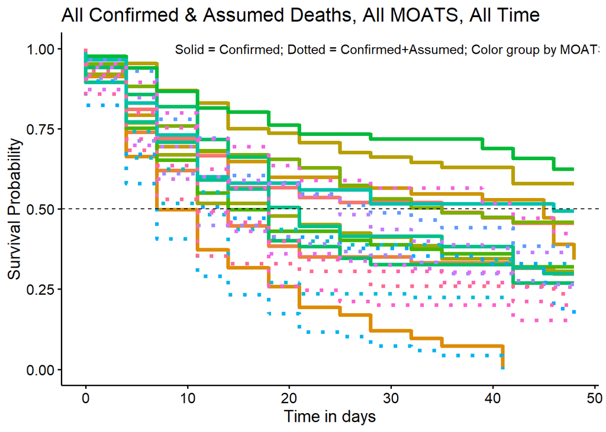

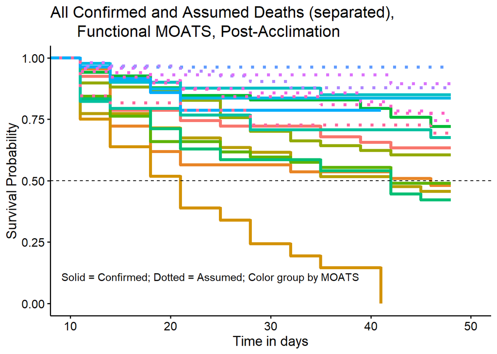

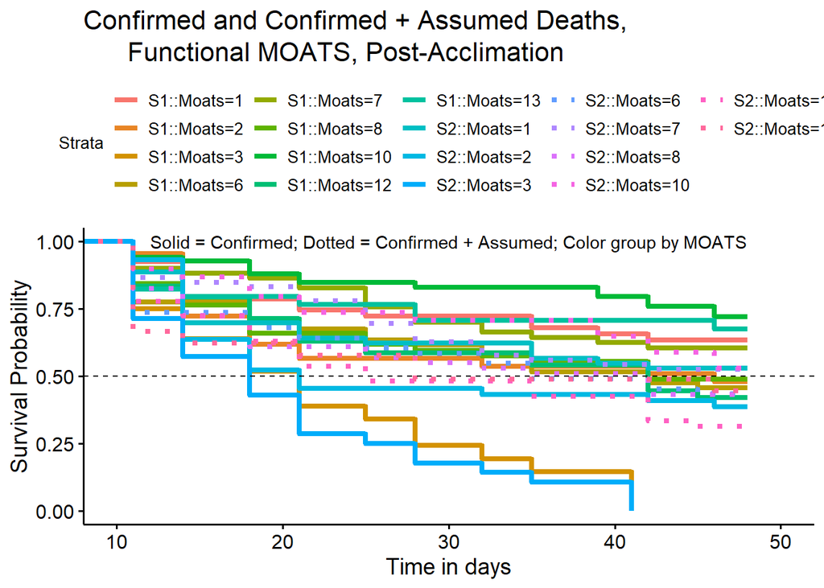

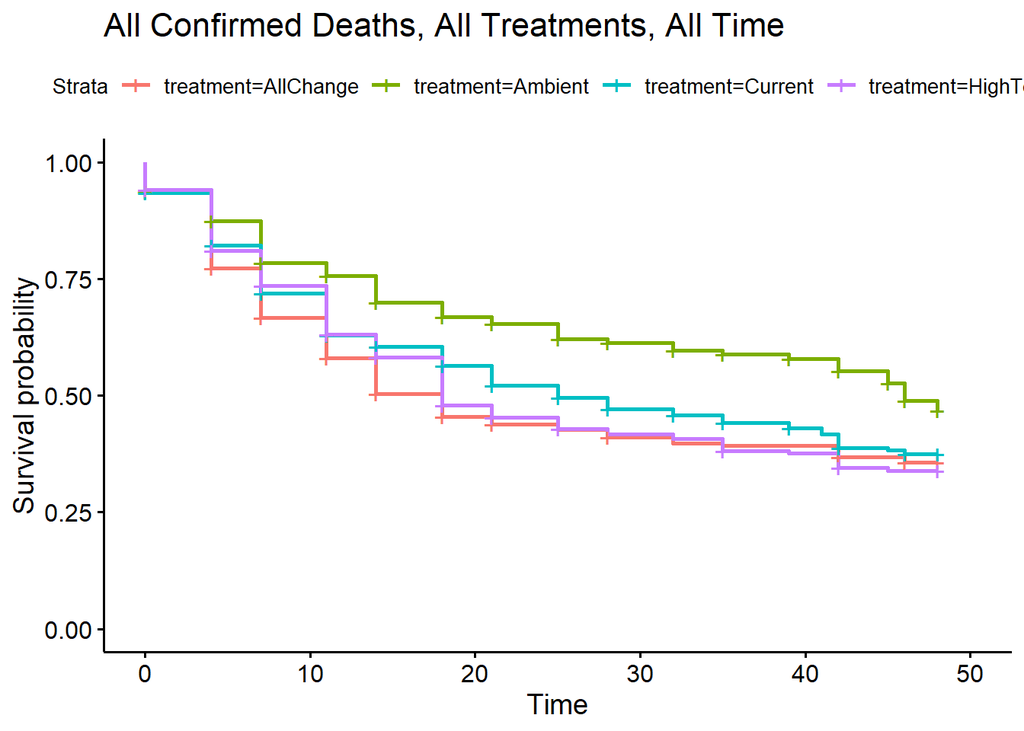

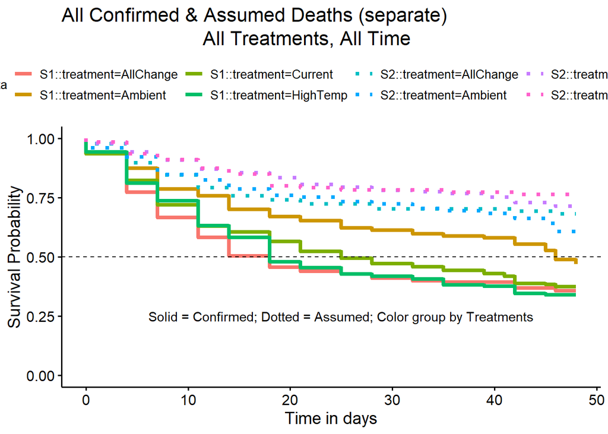

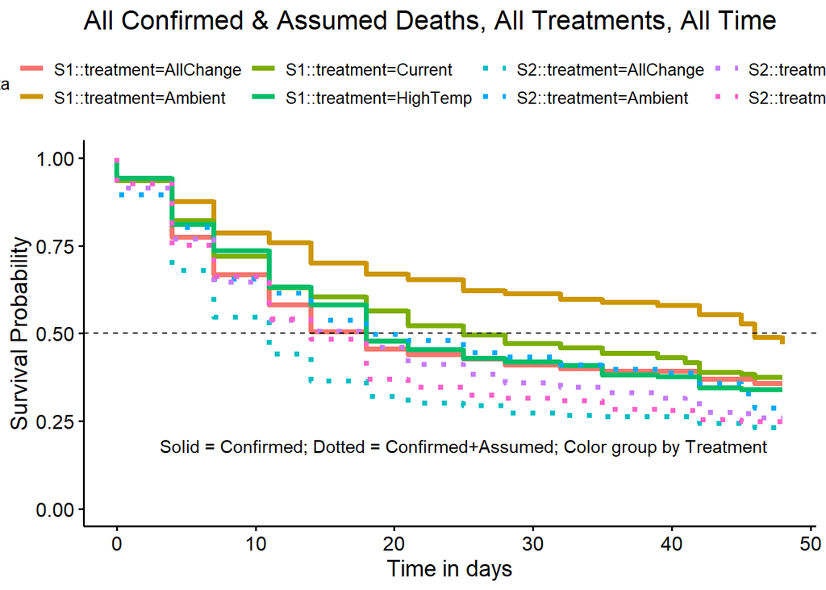

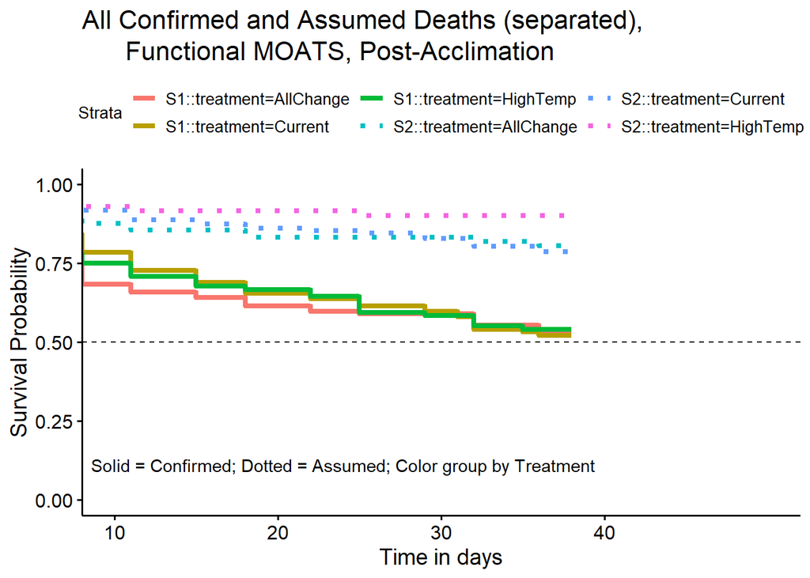

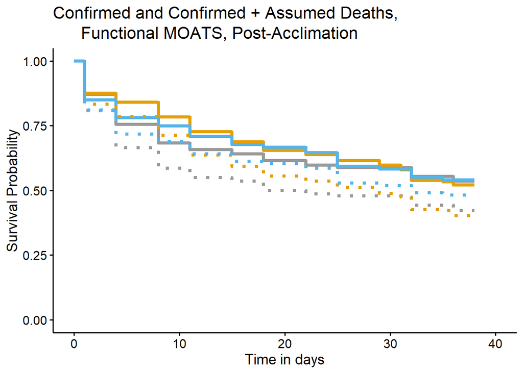

frailtyEM

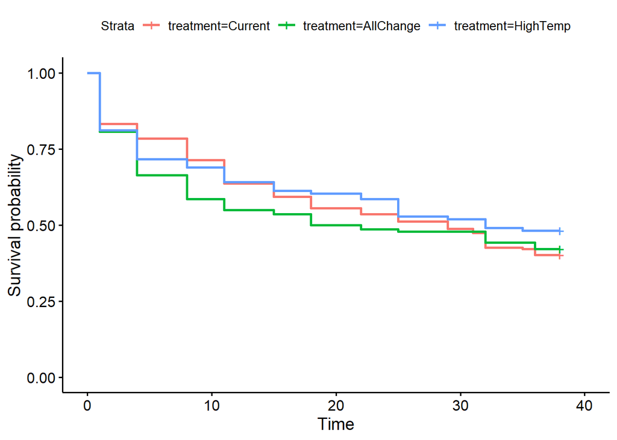

```r
#moats 3 is a bit of an outlier. if it is removed, the frailty disappears
d <- dfAcclGoodMoats %>%
#  filter(Moats != 3) %>%
  {.}

#define the original treatment levels for sorting out contrasts
origTreatLevels <- levels(d$treatment)

#make surv object
surv = Surv(time = d$Day, d$totalDeathEvent, type = "right")

# fit model and plot without random effect
# This is just for visual comparison of the plots
sf <- survfit(surv ~ treatment, data = d)
ggsurvplot(sf)
```

```r
summary(coxph(surv ~ treatment, data = d))
```

```
## Call:
## coxph(formula = surv ~ treatment, data = d)
##
##   n= 455, number of events= 261
##
##                        coef exp(coef) se(coef)      z Pr(>|z|)
## treatmentAllChange  0.03975   1.04055  0.14271  0.279    0.781
## treatmentHighTemp  -0.14591   0.86423  0.16185 -0.902    0.367
##
##                    exp(coef) exp(-coef) lower .95 upper .95
## treatmentAllChange    1.0405      0.961    0.7867     1.376
## treatmentHighTemp     0.8642      1.157    0.6293     1.187
##
## Concordance= 0.521  (se = 0.019 )
## Likelihood ratio test= 1.24  on 2 df,   p=0.5
## Wald test            = 1.21  on 2 df,   p=0.5
## Score (logrank) test = 1.21  on 2 df,   p=0.5
```

```r
#find the frailty distribution with the maximum likelihood
# Note: the for loop can be kinda slow because it is fitting all four models
frailtyDist <- data.frame(name = c("gamma", "stablePos", "invGausian", "nonCenGamma"),
  dist = c("gamma", "stable", "pvf", "pvf"), m = c(0, 0, -0.5, 1))
dLike <- NULL
for(i in 1:length(frailtyDist$name)){
  mLogLike <- emfrail(surv ~ treatment + cluster(Moats),
                  distribution = emfrail_dist(dist = frailtyDist$dist[i], pvfm = frailtyDist$m[i]),
                  data = d)$loglik[2]
  dTemp <- data.frame(dist = frailtyDist$name[i], logLike = mLogLike)
  dLike <- rbind(dLike, dTemp)
}
#identify the model frailty distribution with the maximum likelihood
bestDist <- dLike$dist[dLike$logLike == max(dLike$logLike)]


# fit model with moats random effect using best fit frailty distribution
#reorder levels for treatment contrast
d$treatment <- relevel(d$treatment, ref = origTreatLevels[1])
fme <- emfrail(surv ~ treatment + cluster(Moats),
                  distribution = emfrail_dist(dist = frailtyDist$dist[frailtyDist$name == bestDist],
                                           pvfm = frailtyDist$m[frailtyDist$name == bestDist] ),
                  data = d)
summary(fme)
```

```
## Call:
## emfrail(formula = surv ~ treatment + cluster(Moats), data = d,
##     distribution = emfrail_dist(dist = frailtyDist$dist[frailtyDist$name ==
##         bestDist], pvfm = frailtyDist$m[frailtyDist$name == bestDist]))
##
## Regression coefficients:
##                     coef exp(coef) se(coef) adj. se     z    p
## treatmentAllChange 0.219     1.244    0.195   0.195 1.122 0.26
## treatmentHighTemp  0.035     1.036    0.217   0.217 0.161 0.87
## Estimated distribution: stable / left truncation: FALSE
##
## Fit summary:
## Commenges-Andersen test for heterogeneity: p-val  0.00417
## no-frailty Log-likelihood: -1515.899
## Log-likelihood: -1509.953
## LRT: 1/2 * pchisq(11.9), p-val 0.000282
##
## Frailty summary:
##                    estimate lower 95% upper 95%
## Kendall's tau         0.045     0.004     0.152
## Median concordance    0.044     0.004     0.149
## E[logZ]               0.027     0.002     0.104
## Var[logZ]             0.159     0.012     0.644
## Attenuation           0.955     0.848     0.996
## theta                21.170     5.567   266.320
## Confidence intervals based on the likelihood function
```

```r
#reorder levels for treatment contrast
d$treatment <- relevel(d$treatment, ref = origTreatLevels[2])
fme2 <- emfrail(surv ~ treatment + cluster(Moats),
                  distribution = emfrail_dist(dist = "stable"),
                  data = d)

summary(fme2)
```

```
## Call:
## emfrail(formula = surv ~ treatment + cluster(Moats), data = d,
##     distribution = emfrail_dist(dist = "stable"))
##
## Regression coefficients:
##                     coef exp(coef) se(coef) adj. se      z    p
## treatmentCurrent  -0.219     0.804    0.195   0.195 -1.122 0.26
## treatmentHighTemp -0.184     0.832    0.211   0.211 -0.872 0.38
## Estimated distribution: stable / left truncation: FALSE
##
## Fit summary:
## Commenges-Andersen test for heterogeneity: p-val  0.00417
## no-frailty Log-likelihood: -1515.899
## Log-likelihood: -1509.953
## LRT: 1/2 * pchisq(11.9), p-val 0.000282
##
## Frailty summary:
##                    estimate lower 95% upper 95%
## Kendall's tau         0.045     0.004     0.152
## Median concordance    0.044     0.004     0.149
## E[logZ]               0.027     0.002     0.104
## Var[logZ]             0.159     0.012     0.644
## Attenuation           0.955     0.848     0.996
## theta                21.170     5.567   266.320
## Confidence intervals based on the likelihood function
```

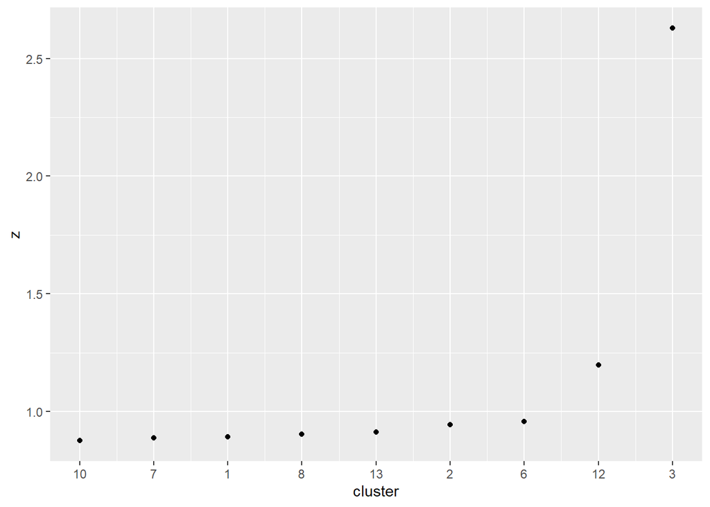

```r
 ####
#frailty plot - shows variation in frailty terms
autoplot(fme, type = "frail")
```

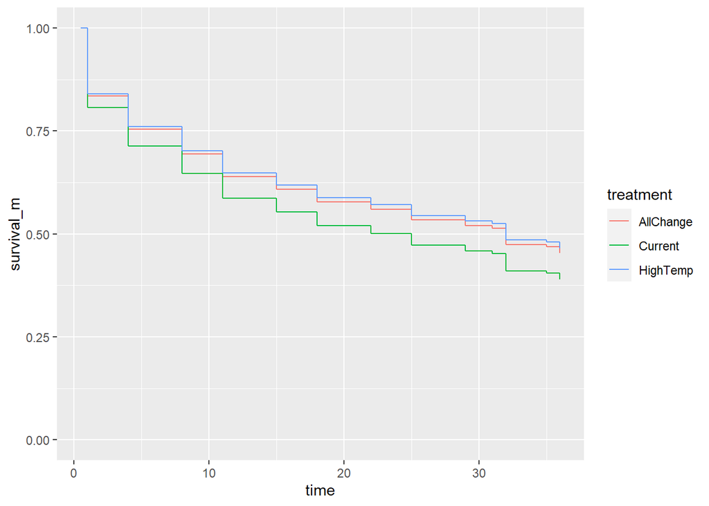

```r
#new data of treatment for survival plots
dNew <- data.frame(treatment = unique(dfAcclGoodMoats$treatment))
#predictions (survival probabilities) of treatments
pred <- predict(fme, newdata = dNew, conf_int = "adjusted")

#create a data frame of the predictions for plotting all the treatment curves
dPlot <- NULL
for(i in 1:length(pred)){
  dTemp <- pred[[i]] %>%
    mutate(treatment = levels(d$treatment)[i])
  dPlot <- rbind(dPlot, dTemp)
}
#plot marginal survival curves
# TODO fit the frailtyEM model of the other survival estimate (estimated dead) and plot curves
# TODO Make the plot pretty
# TODO could and confidence bands or ribbons with dPlot$survival_m_l_a and dPlot$survival_m_r_a, but that would probably the graph too messy
ggplot(dPlot, aes(time, survival_m)) +
  geom_step(aes( color = treatment)) +
  ylim(0,1) +
  geom_blank()
```

```r
# TODO cleanup the frailtyEM text so it is manuscript ready
```

Survival in the three treatments was compared using a hazard model that included the MOATS as a clustered frailty term. The frailty model was fit using the frailtyEM R package [ref]. Preliminary analyses was conducted to compare four potential distribution of the frailty (gamma, positive stable, inverse Gausian and non-central gamma). The positive stable distribution had the greatest likelihood value and it was selected for the final analysis (Balan and Putter). Using a likelihood ratio test, inclusion of the frailty term was deemed significant when compared to the treatment only hazards model (p = 0.000282). Likewise, the presence of unexplained heterogeneity in the simple non-frailty model suggests appropriate inclusion of the frailty (MOATS) term (Commenges-Andersen test p = 0.00417). There were no significant differences among pair-wise comparisons of the treatments (all vs. current p = 0.26; all vs. highT p = 0.38; current vs. highT p = 0.87). The graph plots the marginal survival curves comparing treatments integrated over the MOATS frailty effect.

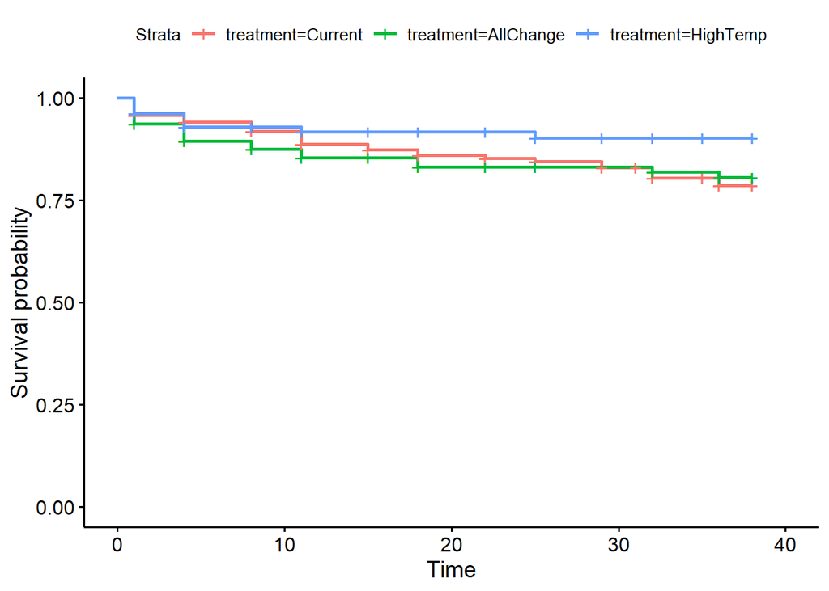

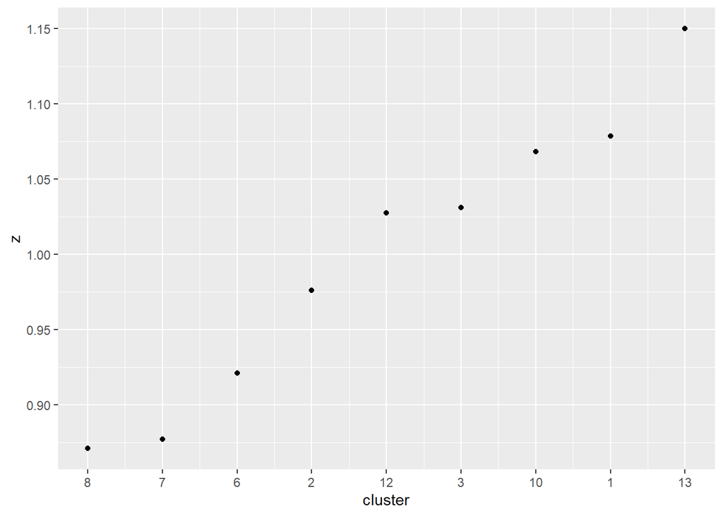

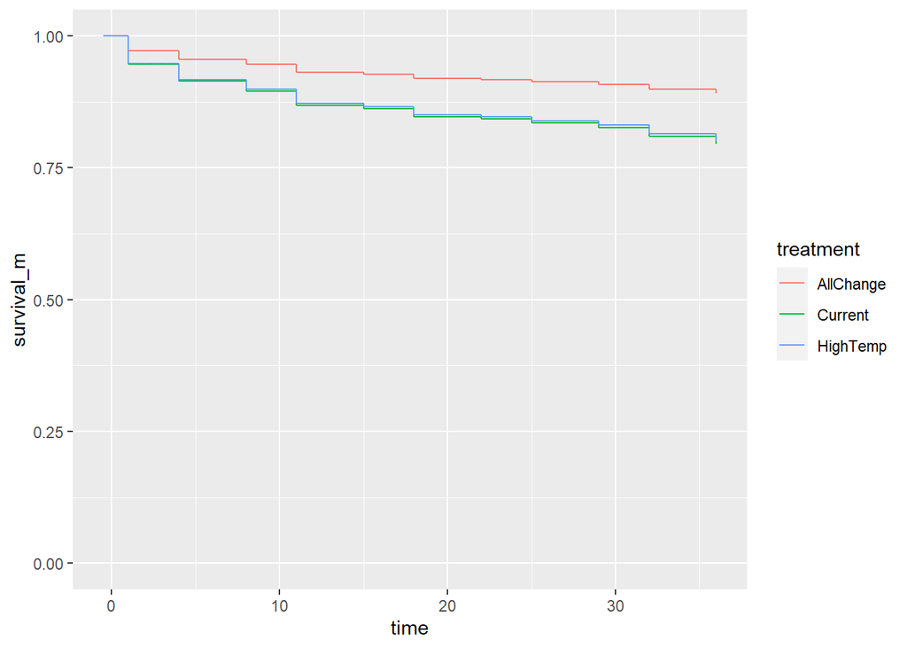